# Self-Driving Car Engineer Nanodegree

## Project: Build a Traffic Sign Recognition Classifier

In this notebook, a template is provided for you to implement your functionality in stages, which is required to successfully complete this project. If additional code is required that cannot be included in the notebook, be sure that the Python code is successfully imported and included in your submission if necessary.

In addition to implementing code, there is a writeup to complete. The writeup should be completed in a separate file, which can be either a markdown file or a pdf document. There is a [write up template](https://github.com/udacity/CarND-Traffic-Sign-Classifier-Project/blob/master/writeup_template.md) that can be used to guide the writing process. Completing the code template and writeup template will cover all of the [rubric points](https://review.udacity.com/#!/rubrics/481/view) for this project.

The [rubric](https://review.udacity.com/#!/rubrics/481/view) contains "Stand Out Suggestions" for enhancing the project beyond the minimum requirements. The stand out suggestions are optional. If you decide to pursue the "stand out suggestions", you can include the code in this Ipython notebook and also discuss the results in the writeup file.

> **Note:** Code and Markdown cells can be executed using the **Shift + Enter** keyboard shortcut. In addition, Markdown cells can be edited by typically double-clicking the cell to enter edit mode.

## Step 0: Load The Data

```python
# Load pickled data
import pickle

# TODO: Fill this in based on where you saved the training and testing data

training_file =  '/home/jesse/Downloads/traffic_signs_data/train.p' # NB read only default
validation_file= '/home/jesse/Downloads/traffic_signs_data/valid.p'
testing_file =   '/home/jesse/Downloads/traffic_signs_data/test.p'

with open(training_file, mode='rb') as f: # mode Read Binary
    train = pickle.load(f)
with open(validation_file, mode='rb') as f:
    valid = pickle.load(f)
with open(testing_file, mode='rb') as f:
    test = pickle.load(f)

X_train, y_train = train['features'], train['labels']
X_valid, y_valid = valid['features'], valid['labels']
X_test, y_test = test['features'], test['labels']
```

## Step 1: Dataset Summary & Exploration

The pickled data is a dictionary with 4 key/value pairs:

- `'features'` is a 4D array containing raw pixel data of the traffic sign images, (num examples, width, height, channels).
- `'labels'` is a 1D array containing the label/class id of the traffic sign. The file `signnames.csv` contains id -> name mappings for each id.
- `'sizes'` is a list containing tuples, (width, height) representing the original width and height the image.
- `'coords'` is a list containing tuples, (x1, y1, x2, y2) representing coordinates of a bounding box around the sign in the image. **THESE COORDINATES ASSUME THE ORIGINAL IMAGE. THE PICKLED DATA CONTAINS RESIZED VERSIONS (32 by 32) OF THESE IMAGES**

Complete the basic data summary below. Use python, numpy and/or pandas methods to calculate the data summary rather than hard coding the results. For example, the [pandas shape method](http://pandas.pydata.org/pandas-docs/stable/generated/pandas.DataFrame.shape.html) might be useful for calculating some of the summary results.

### 1.1 Provide a Basic Summary of the Data Set Using Python, Numpy and/or Pandas

```python
### Replace each question mark with the appropriate value.
### Use python, pandas or numpy methods rather than hard coding the results

import numpy as np
import pandas as pd

# TODO: Number of training examples
n_train = X_train.shape[0]

# TODO: Number of validation examples
n_validation = X_valid.shape[0]

# TODO: Number of testing examples.
n_test = X_test.shape[0]

# TODO: What's the shape of an traffic sign image?
image_shape = X_train.shape[1:4] # index multiple dims - from 1 incl to 4 excl

# TODO: How many unique classes/labels there are in the dataset.
n_classes = len(set(y_train))

print("Number of training examples =", n_train)
print("Number of validation examples =", n_validation)
print("Number of testing examples =", n_test)
print("Image data shape =", image_shape)
print("Number of classes =", n_classes)
```

```
Number of training examples = 34799
Number of validation examples = 4410
Number of testing examples = 12630
Image data shape = (32, 32, 3)
Number of classes = 43
```

### 1.2 Include an exploratory visualization of the dataset

Visualize the German Traffic Signs Dataset using the pickled file(s). This is open ended, suggestions include: plotting traffic sign images, plotting the count of each sign, etc.

The [Matplotlib](http://matplotlib.org/) [examples](http://matplotlib.org/examples/index.html) and [gallery](http://matplotlib.org/gallery.html) pages are a great resource for doing visualizations in Python.

**NOTE:** It's recommended you start with something simple first. If you wish to do more, come back to it after you've completed the rest of the sections. It can be interesting to look at the distribution of classes in the training, validation and test set. Is the distribution the same? Are there more examples of some classes than others?

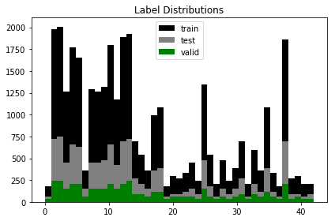

```
(15.738297077502228, 12.002396466891161)
```

```python
### Data exploration visualization code goes here.
### Feel free to use as many code cells as needed.
import matplotlib.pyplot as plt
# Visualizations will be shown in the notebook.
%matplotlib inline


# Plot Histograms of 3 data sets (labels - distribution looks the same)
plt.hist(y_train, bins=43, color='black', label="train")
plt.hist(y_test, bins=43, color='gray', label="test")
plt.hist(y_valid, bins=43, color='g', label="valid")
plt.title("Label Distributions")
plt.legend()
plt.tight_layout()
plt.savefig('Label_Distributions.png')
plt.show()

# verify with eg % distribution - needs operation
#train_valid = y_train/y_valid
#train_test = y_train/y_test
#test_valid = y_test/y_valid

#
np.mean(y_train), np.std(y_train)
```

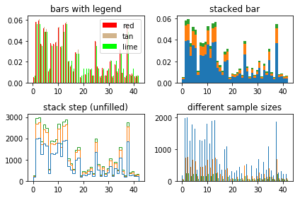

```python
# https://matplotlib.org/examples/statistics/histogram_demo_multihist.html
np.random.seed(0)

n_bins = 43
x = np.array([y_train, y_test, y_valid])

fig, axes = plt.subplots(nrows=2, ncols=2)
ax0, ax1, ax2, ax3 = axes.flatten()

colors = ['red', 'tan', 'lime']
ax0.hist(x, n_bins, normed=1, histtype='bar', color=colors, label=colors)
ax0.legend(prop={'size': 10})
ax0.set_title('bars with legend')

ax1.hist(x, n_bins, normed=1, histtype='bar', stacked=True)
ax1.set_title('stacked bar')

ax2.hist(x, n_bins, histtype='step', stacked=True, fill=False)
ax2.set_title('stack step (unfilled)')

# Make a multiple-histogram of data-sets with different length.
ax3.hist(x, n_bins, histtype='bar')
ax3.set_title('different sample sizes')

fig.tight_layout()
fig.savefig("Label_Plots.png")
plt.show()
```

#### Observations

There appears to be valid-train-test homogeneity (ebi confirm numerically).

However some signs are much more common than others. Speed limit signs are generally (but not uniformly) over-represented. Lots of important signs are under-represented (danger children etc).

#### Examine labels

```python
# Decode
signnames = np.loadtxt('signnames.csv', dtype=str, delimiter=',')
#print(type(signnames))
print(signnames[0,])
print(signnames[1,]) # y_train=0 means "20km/h"; this happens when signnames index is 1
print(signnames[42,])
print(signnames[43,])
```

```
['ClassId' 'SignName']
['0' 'Speed limit (20km/h)']
['41' 'End of no passing']
['42' 'End of no passing by vehicles over 3.5 metric tons']
```

## Step 2: Design and Test a Model Architecture

Design and implement a deep learning model that learns to recognize traffic signs. Train and test your model on the [German Traffic Sign Dataset](http://benchmark.ini.rub.de/?section=gtsrb&subsection=dataset).

The LeNet-5 implementation shown in the classroom at the end of the CNN lesson is a solid starting point. You'll have to change the number of classes and possibly the preprocessing, but aside from that it's plug and play!

With the LeNet-5 solution from the lecture, you should expect a validation set accuracy of about 0.89. To meet specifications, the validation set accuracy will need to be at least 0.93. It is possible to get an even higher accuracy, but 0.93 is the minimum for a successful project submission.

There are various aspects to consider when thinking about this problem:

- Neural network architecture (is the network over or underfitting?)
- Play around preprocessing techniques (normalization, rgb to grayscale, etc)
- Number of examples per label (some have more than others).
- Generate fake data.

Here is an example of a [published baseline model on this problem](http://yann.lecun.com/exdb/publis/pdf/sermanet-ijcnn-11.pdf). It's not required to be familiar with the approach used in the paper but, it's good practice to try to read papers like these.

### 2.1 Pre-process the Data Set (normalization, grayscale, etc.)

Minimally, the image data should be normalized so that the data has mean zero and equal variance. For image data, `(pixel - 128)/ 128` is a quick way to approximately normalize the data and can be used in this project.

Other pre-processing steps are optional. You can try different techniques to see if it improves performance.

Use the code cell (or multiple code cells, if necessary) to implement the first step of your project.

### 2.1.1 Helper functions

```python
### Preprocess the data here. It is required to normalize the data. Other preprocessing steps could include
### converting to grayscale, etc.
### Feel free to use as many code cells as needed.

import cv2
seed = 32

# The following is not used since it worsened performance; probably because it uses MATLAB-style weights designed to
# replicate human perception (green is hugely overweight)
# Convert to grayscale
def gray(img):
    img_ = img.astype(np.uint8)
    gray = cv2.cvtColor(img_, cv2.COLOR_RGB2GRAY)
    gray_ = gray.astype(np.uint8)
    return gray_

# Credit Medium piece on this project
# Convert grayscale to histogram equalise using cv2

def equalize(img):
    img_=img.astype(np.uint8)
    equal = cv2.equalizeHist(img_)
    return equal

def norm_basic(img): # why doesn't this do what I want? outputs b/w image
    out = ((img-128)/128).astype(np.uint8)
    return (out)

def merge(img_1, alpha, img_2, beta, gamma=0):
    out = cv2.addWeighted(img_1, alpha, img_2, beta, gamma)
    return out

def add_Gauss_noise(img, color=True, rate=0.1):
    '''
    Adds rate*noise to (1-rate)*img; returns a blend. Enter color=False for grayscale image.
    '''
    np.random.seed(seed=seed)
    ones = np.ones_like(img)
    if color:
        noise = (np.random.randn(ones.shape[0], ones.shape[1], ones.shape[2])*128+128).astype(np.uint8)
    else:
        noise = (np.random.randn(ones.shape[0])*128+128).astype(np.uint8)
    merged = merge(img_1=img, alpha=1-rate, img_2=noise, beta=rate, gamma=0)
    return merged

def center(img):
    return (img-np.mean(img)).astype(np.uint8)
```

```python
# Define transformation functions
# Credit: github.vxy10/ImageAugmentation

def augment_brightness_camera_images(image):
    image1 = cv2.cvtColor(image, cv2.COLOR_RGB2HSV)
    random_bright = 0.25+np.random.uniform()
    #print(random_bright)
    image1[:,:,2]=image1[:,:,2]*random_bright
    image1 = cv2.cvtColor(image1, cv2.COLOR_HSV2RGB)
    return image1

def transform_image(img, ang_range, shear_range, trans_range, brightness=0):
    '''
    This function transforms images to generate new images: rotation, shear, translation and brighten.
    A random uniform distribution is used to generate different parameters for transformation.
    Set "brightness=1" to augment brightness; ranges take floats.
    '''
    # Rotation
    ang_rot = np.random.uniform(ang_range)-ang_range/2
    rows, cols, ch = img.shape
    Rot_M = cv2.getRotationMatrix2D((cols/2,rows/2), ang_rot, 1)

    # Translation
    tr_x = trans_range * np.random.uniform()-trans_range/2
    tr_y = trans_range * np.random.uniform()-trans_range/2
    Trans_M = np.float32([[1,0,tr_x],[0,1,tr_y]])

    # Shear
    pts1 = np.float32([[5,5],[20,5],[5,20]]) # are these numbers 32x32-friendly?
    pt1 = 5+shear_range*np.random.uniform()-shear_range/2
    pt2 = 20+shear_range*np.random.uniform()-shear_range/2

    # Brightness
    # Seperate function


    pts2 = np.float32([[pt1,5],[pt2,pt1],[5,pt2]])

    Shear_M = cv2.getAffineTransform(pts1, pts2)

    img = cv2.warpAffine(img, Rot_M, (cols,rows))
    img = cv2.warpAffine(img, Trans_M, (cols, rows))
    img = cv2.warpAffine(img, Shear_M, (cols,rows))

    if brightness == 1:
        img = augment_brightness_camera_images(img)

    return img
```

[figure not shown]

```python
#Apply above functions to img_20kmh
#img_20kmh = mpimg.imread(img_20kmh)

import matplotlib.gridspec as gridspec
import matplotlib.image as mpimg

gs1 = gridspec.GridSpec(10,10)
gs1.update(wspace=0.01, hspace=0.02) # set spacing between axes
plt.figure(figsize=(12,12))
for i in range(100):
    ax1 = plt.subplot(gs1[i])
    ax1.set_xticklabels([])
    ax1.set_yticklabels([])
    ax1.set_aspect('equal')
    img = transform_image(X_train[10000], 20,10,5,brightness=1)

    plt.subplot(10,10,i+1)
    plt.imshow(img)
    plt.axis('off')

plt.savefig("100_generated.png")
plt.show()
```

### Generate Data

```python
# Do the counts (Which data do we need to supplement (artifically)?)

d_train = np.zeros((43))
for i in range(43):
    fre = sum(y_train==i)
    d_train[i]=fre

d_valid = np.zeros((43))
for i in range(43):
    fre = sum(y_valid==i)
    d_valid[i]=fre

d_test = np.zeros((43))
for i in range(43):
    fre = sum(y_test==i)
    d_test[i]=fre
```

```python
# Which columns are outliers?
print(np.mean(d_train),np.std(d_train))
print(np.median(d_train))
# With std=mean (approx), no data are outliers... . Max=10*min for all three datasets.
# NB don't mess with the valid or test sets!
print(np.argmax(d_train))
print(np.max(d_train), np.min(d_train), np.max(d_valid), np.min(d_valid), np.max(d_test), np.min(d_test))

# Let's generate otoo 1000 data for about 3/4 of the labels.

print(d_train<1000)
print((d_train<2000)*(2000-d_train)) # how many new data to create in each index
print(np.sum((d_train<2000)*(2000-d_train)))

#for value, index in
```

```
809.279069767 619.420183705
540.0
2
2010.0 180.0 240.0 30.0 750.0 60.0
[ True False False False False False  True False False False False False
 False False  True  True  True  True False  True  True  True  True  True
  True False  True  True  True  True  True  True  True  True  True False
  True  True False  True  True  True  True]
[ 1820.    20.    -0.   740.   230.   350.  1640.   710.   740.   680.
   200.   830.   110.    80.  1310.  1460.  1640.  1010.   920.  1820.
  1700.  1730.  1670.  1550.  1760.   650.  1460.  1790.  1520.  1760.
  1610.  1310.  1790.  1401.  1640.   920.  1670.  1820.   140.  1730.
  1700.  1790.  1790.]
51211.0
```

```python
# Perform Generation
decision_boolean = d_train<2000
num_to_gen       = (d_train<2000)*(2000-d_train)

generated_image_list = []
gen_labels_list = []

for label in range(43):
    testCounter=0 # delete when finished
    if decision_boolean[label] == True:
        num_to_gen_temp = int(num_to_gen[label])
        num_originals_to_trans = int(num_to_gen_temp / 100)
        print('label= ',label, 'originals to transf : ', num_originals_to_trans)

        # select however many images to transform
        i = 0 # for each of the 18 i-values, transform 100 images
        while i < num_originals_to_trans: # 18 for first label; i=0,1,2,...,17
            # then for each one, generate 100 new images
            for index, label_temp in enumerate(y_train): # (0,43),(1,12),(2,0),...,(25k,27)
                if i < num_originals_to_trans and label_temp == label: # whenever y_train has value '0' eg (2,0)
                    img_temp = X_train[index] # select X_train[2] (an image corresponding to label=0)
                    # generate & store*2 100 images from gen_new(img_temp)
                    j = 0
                    while j < 100: # change back to 100 after testing
                        img = transform_image(img_temp, 10,5,2,brightness=0) # 20,10,5,1
                        generated_image_list.append(img) # append images
                        gen_labels_list.append(label) # and labels
                        j += 1 # until 100 have been created
                    testCounter+=1
                    i += 1 # goes up each time new image is chosen (and multiplied)
    print(testCounter) # delete when finished
```

```
label=  0 originals to transf :  18
18
label=  1 originals to transf :  0
0
0
label=  3 originals to transf :  7
7
label=  4 originals to transf :  2
2
label=  5 originals to transf :  3
3
label=  6 originals to transf :  16
16
label=  7 originals to transf :  7
7
label=  8 originals to transf :  7
7
label=  9 originals to transf :  6
6
label=  10 originals to transf :  2
2
label=  11 originals to transf :  8
8
label=  12 originals to transf :  1
1
label=  13 originals to transf :  0
0
label=  14 originals to transf :  13
13
label=  15 originals to transf :  14
14
label=  16 originals to transf :  16
16
label=  17 originals to transf :  10
10
label=  18 originals to transf :  9
9
label=  19 originals to transf :  18
18
label=  20 originals to transf :  17
```

[output cut: 30 more lines]

```
9
label=  36 originals to transf :  16
16
label=  37 originals to transf :  18
18
label=  38 originals to transf :  1
1
label=  39 originals to transf :  17
17
label=  40 originals to transf :  17
17
label=  41 originals to transf :  17
17
label=  42 originals to transf :  17
17
```

```
new:  16
CSV:  ['16' 'Vehicles over 3.5 metric tons prohibited']
```

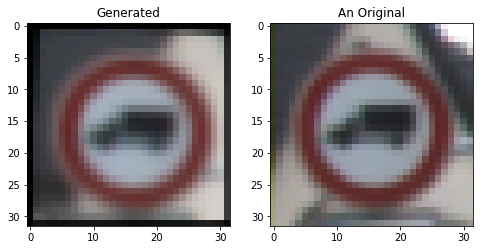

```python
# Reality check - make sure images have correct label (see csv!), are different etc
i=10678
print('new: ', gen_labels_list[i]) # y=36, corresponding to signnames[37,] = "go straight or right"
print('CSV: ', signnames[gen_labels_list[i]+1,])

# Get an original
check_i = -1
target = signnames[gen_labels_list[i]+1,][0]
#print(target)
for index, value in enumerate(y_train):
    #print (index,str(value),target,value==target,type(value),type(target))
    if str(value) == target:
        check_i = index
        break

# Plot
fig = plt.figure(figsize=(8,16))

a = fig.add_subplot(121)
a.set_title("Generated")
plt.imshow(generated_image_list[i])

a = fig.add_subplot(122)
a.set_title("An Original")
plt.imshow(X_train[check_i])

plt.show()
```